# Sales Forecasting for Walmart

Author

Zenan Dong

Published

February 26, 2025

# 1 Project Background & Business Objectives

In the retail industry, sales forecasting is a critical component of business decision-making. Walmart, as one of the world’s leading retailers, not only has rich time series sales data but also faces influences from promotions, holidays, and macroeconomic factors (such as temperature, fuel price, CPI, and unemployment rate). The main objectives of this project are:

- **Build Multiple Forecasting Models:** Develop forecasting models using Prophet, ARIMA, and a machine learning–based Random Forest to predict sales data.
- **Compare Model Performance:** Evaluate different models using error metrics (RMSE, MAE, MAPE) and forecast visualizations to provide data-driven insights for business decisions.
- **Business Analysis Perspective:** Analyze how the forecast results impact inventory management, promotional activities, and resource allocation to guide strategic optimizations.

# 2 Data Preparation & Exploration

The project uses sales data from Walmart, along with store information, promotional data, and economic indicators. Initially, the data is cleaned, date formats are standardized, and datasets are merged. This process ensures that all raw data are correctly imported and column names are standardized, preventing conflicts or errors during merging. After merging, information from various data sources is consolidated to provide a rich set of variables for subsequent exploratory analysis and modeling. Additionally, converting all dates into a uniform format facilitates the construction of time series features.

```
# A tibble: 6 × 16
  store  dept date       weekly_sales type    size temperature fuel_price
  <dbl> <dbl> <date>            <dbl> <chr>  <dbl>       <dbl>      <dbl>
1     1     1 2010-02-05       24924. A     151315        42.3       2.57
2     1     1 2010-02-12       46039. A     151315        38.5       2.55
3     1     1 2010-02-19       41596. A     151315        39.9       2.51
4     1     1 2010-02-26       19404. A     151315        46.6       2.56
5     1     1 2010-03-05       21828. A     151315        46.5       2.62
6     1     1 2010-03-12       21043. A     151315        57.8       2.67
# ℹ 8 more variables: mark_down1 <dbl>, mark_down2 <dbl>, mark_down3 <dbl>,
#   mark_down4 <dbl>, mark_down5 <dbl>, cpi <dbl>, unemployment <dbl>,
#   is_holiday <lgl>
```

## 2.1 Basic Statistics & Business Insights

In this section, we use summary statistics and visualizations to understand the data distribution, store sales performance, and promotional coverage. These findings will direct subsequent modeling efforts and reveal the current sales scenario to decision-makers.

### 2.1.1 Store Sales Overview

Sales Summary by Store

| store | avg_weekly_sales | total_sales | records |
| --- | --- | --- | --- |
| 20 | 29508.302 | 301397792 | 10214 |
| 4 | 29161.210 | 299543953 | 10272 |
| 14 | 28784.852 | 288999911 | 10040 |
| 13 | 27355.137 | 286517704 | 10474 |
| 2 | 26898.070 | 275382441 | 10238 |
| 10 | 26332.304 | 271617714 | 10315 |
| 27 | 24826.985 | 253855917 | 10225 |
| 6 | 21913.244 | 223756131 | 10211 |
| 1 | 21710.544 | 222402809 | 10244 |
| 39 | 21000.764 | 207445542 | 9878 |
| 19 | 20362.127 | 206634862 | 10148 |
| 31 | 19681.907 | 199613906 | 10142 |
| 23 | 19776.181 | 198750618 | 10050 |
| 24 | 18969.106 | 194016021 | 10228 |
| 11 | 19276.763 | 193962787 | 10062 |
| 28 | 18714.890 | 189263681 | 10113 |
| 41 | 17976.005 | 181341935 | 10088 |
| 32 | 16351.622 | 166819246 | 10202 |
| 18 | 15733.313 | 155114734 | 9859 |
| 22 | 15181.219 | 147075649 | 9688 |
| 12 | 14867.309 | 144287230 | 9705 |
| 26 | 14554.130 | 143416394 | 9854 |
| 34 | 13522.082 | 138249763 | 10224 |
| 40 | 13763.633 | 137870310 | 10017 |
| 35 | 13803.597 | 131520672 | 9528 |
| 8 | 13133.015 | 129951181 | 9895 |
| 17 | 12954.394 | 127782139 | 9864 |
| 45 | 11662.897 | 112395341 | 9637 |
| 21 | 11283.435 | 108117879 | 9582 |
| 25 | 10308.158 | 101061179 | 9804 |
| 43 | 13415.114 | 90565435 | 6751 |
| 15 | 9002.493 | 89133684 | 9901 |
| 7 | 8358.766 | 81598275 | 9762 |
| 42 | 11443.370 | 79565752 | 6953 |
| 9 | 8772.890 | 77789219 | 8867 |
| 29 | 8158.811 | 77141554 | 9455 |
| 16 | 7863.224 | 74252425 | 9443 |
| 37 | 10297.355 | 74202740 | 7206 |
| 30 | 8764.238 | 62716885 | 7156 |
| 3 | 6373.034 | 57586735 | 9036 |
| 38 | 7492.478 | 55159626 | 7362 |
| 36 | 8584.413 | 53412215 | 6222 |
| 5 | 5053.416 | 45475689 | 8999 |
| 44 | 6038.930 | 43293088 | 7169 |
| 33 | 5728.414 | 37160222 | 6487 |

**Business Insight:**  
There are significant differences in sales among the stores. Management can optimize inventory allocation by directing more resources to stores with higher sales while investigating strategies for low-performing stores.

### 2.1.2 Markdown Promotion Statistics

Promotional activities directly affect sales. Since some promotion data are missing, NA values are filled with 0 for proper statistical analysis.

Markdown Columns Statistics

| md1_mean | md1_median | md1_zero | md2_mean | md2_median | md2_zero | md3_mean | md3_median | md3_zero | md4_mean | md4_median | md4_zero | md5_mean | md5_median | md5_zero |
| --- | --- | --- | --- | --- | --- | --- | --- | --- | --- | --- | --- | --- | --- | --- |
| 2590.075 | 0 | 270889 | 879.9743 | 0 | 310529 | 468.0877 | 0 | 284546 | 1083.132 | 0 | 286603 | 1662.772 | 0 | 270138 |

**Business Insight:**  
Promotional information directly influences customer purchasing decisions. By evaluating the coverage and intensity of various promotions, the company can assess their effectiveness and optimize future promotional strategies and budget allocation.

### 2.1.3 Date Range & Other Feature Statistics

Date Range and Record Count

| start_date | end_date | total_weeks |
| --- | --- | --- |
| 2010-02-05 | 2012-10-26 | 143 |

Basic Statistics for Other Features

| temperature_mean | temperature_sd | fuel_price_mean | fuel_price_sd | cpi_mean | cpi_sd | unemployment_mean | unemployment_sd |
| --- | --- | --- | --- | --- | --- | --- | --- |
| 60.09006 | 18.44793 | 3.361026 | 0.4585145 | 171.2019 | 39.15928 | 7.960289 | 1.863296 |

**Business Insight:**  
Understanding the time span and the distribution of external economic indicators helps to gauge their potential impact on sales. For instance, fluctuations in fuel prices may affect consumer travel frequency, indirectly influencing sales performance.

# 3 Exploratory Data Analysis (EDA)

This section uses time series trend plots, sales distribution charts, and correlation matrices to visually reveal data characteristics and the relationships among variables, providing guidance for subsequent modeling.

## 3.1 Sales Distribution & Time Trend

### 3.1.1 Time Trend for a Specific Store and Department:

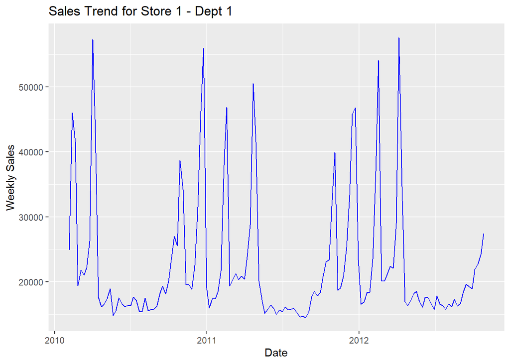

*Explanation:*  
This plot shows the sales trend for a specific store and department, helping to identify overall trends, seasonality, and anomalies that serve as the foundation for selecting an appropriate forecasting model.

### 3.1.2 Overall Sales Distribution (Log Scale):

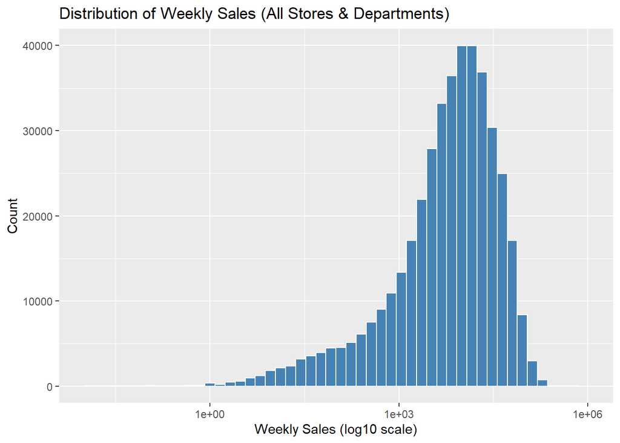

*Explanation:*  
Using a logarithmic scale reveals the long-tail effect and skewed distribution in sales, helping the business understand the central sales range and the presence of extreme values.

## 3.2 Holiday Effects & Correlation Analysis

Sales Comparison on Holidays

| is_holiday | mean_sales | median_sales | records |
| --- | --- | --- | --- |
| FALSE | 15901.45 | 7589.95 | 391909 |
| TRUE | 17035.82 | 7947.74 | 29661 |

*Explanation:*  
By comparing sales on holidays and non-holidays, the analysis reveals the positive impact of promotions or holiday effects on sales, guiding the development of targeted marketing strategies.

```
              weekly_sales  temperature    fuel_price         cpi unemployment
weekly_sales  1.0000000000 -0.002312447 -0.0001202955 -0.02092134  -0.02586372
temperature  -0.0023124470  1.000000000  0.1438588191  0.18211161   0.09673018
fuel_price   -0.0001202955  0.143858819  1.0000000000 -0.16421041  -0.03385270
cpi          -0.0209213353  0.182111607 -0.1642104062  1.00000000  -0.29995302
unemployment -0.0258637165  0.096730180 -0.0338527026 -0.29995302   1.00000000
```

*Explanation:*  
The correlation matrix displays the relationships between weekly sales and external factors like temperature, fuel price, CPI, and unemployment, offering insights for including economic indicators in your forecasting models.

# 4 Feature Engineering

Before modeling, various time series features are constructed—including basic date features, lag variables, and rolling statistics—to help the models capture historical trends and short-term fluctuations. For example, for Store 1 - Dept 1, a plot comparing the rolling mean with actual sales illustrates the effectiveness of the engineered features:

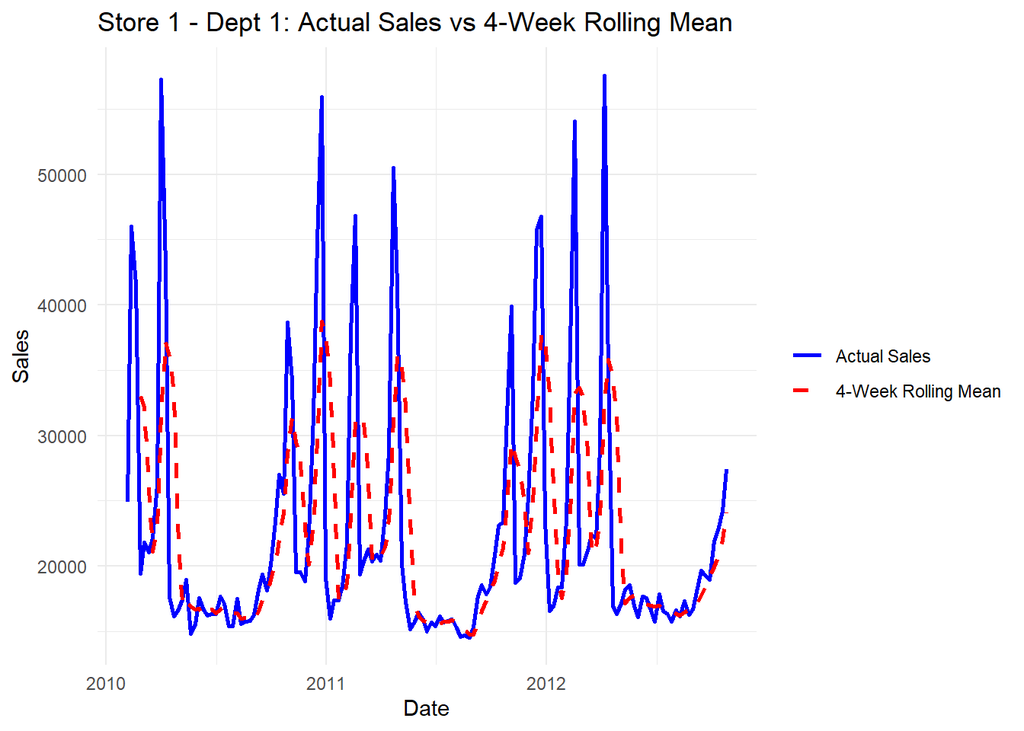

*Explanation:*  
Lag variables and rolling statistics help the model better capture time dependencies, thus improving its ability to forecast trends and short-term fluctuations.

# 5 Model Building & Training

This section details the construction of three forecasting models and discusses their strengths and weaknesses.

## 5.1 Prophet Forecasting

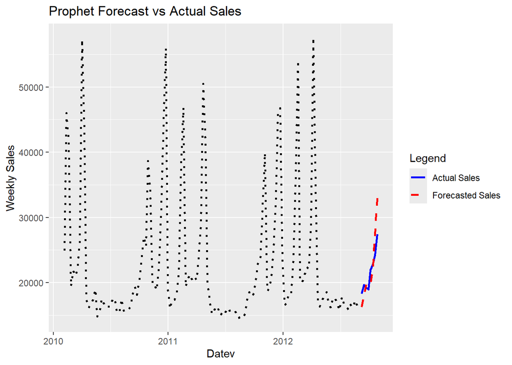

*Explanation:*  
The Prophet model effectively captures seasonality and holiday effects in retail data, reflecting the influence of promotions and holidays on sales.

## 5.2 ARIMA Forecasting

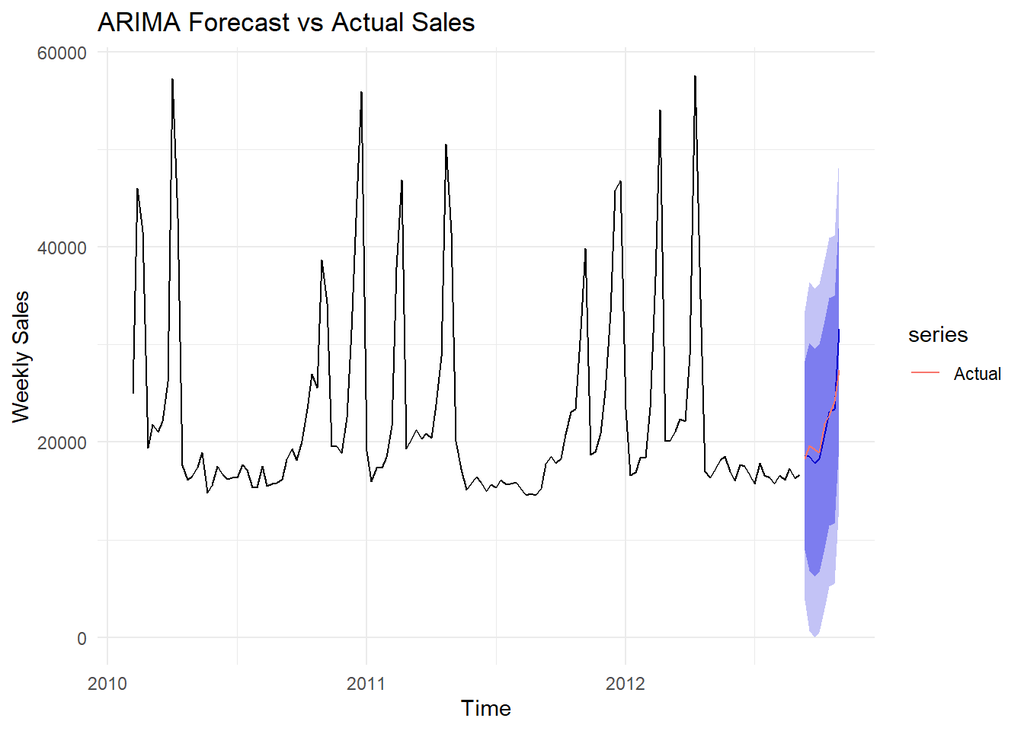

*Explanation:*  
ARIMA captures the autocorrelation within the time series well, especially when the data is stationary, but it may struggle with non-linear changes and external influences.

## 5.3 Random Forest Forecasting (using modeltime & tidymodels):

通过构造时间序列特征以及利用随机森林建模，展示了机器学习方法在时间序列预测中的应用。

```
# A tibble: 1 × 9
  .model_id .model_desc .type   mae  mape  mase smape  rmse   rsq
      <int> <chr>       <chr> <dbl> <dbl> <dbl> <dbl> <dbl> <dbl>
1         1 RANGER      Test  1133.  5.23 0.762  5.18 1316. 0.868
```

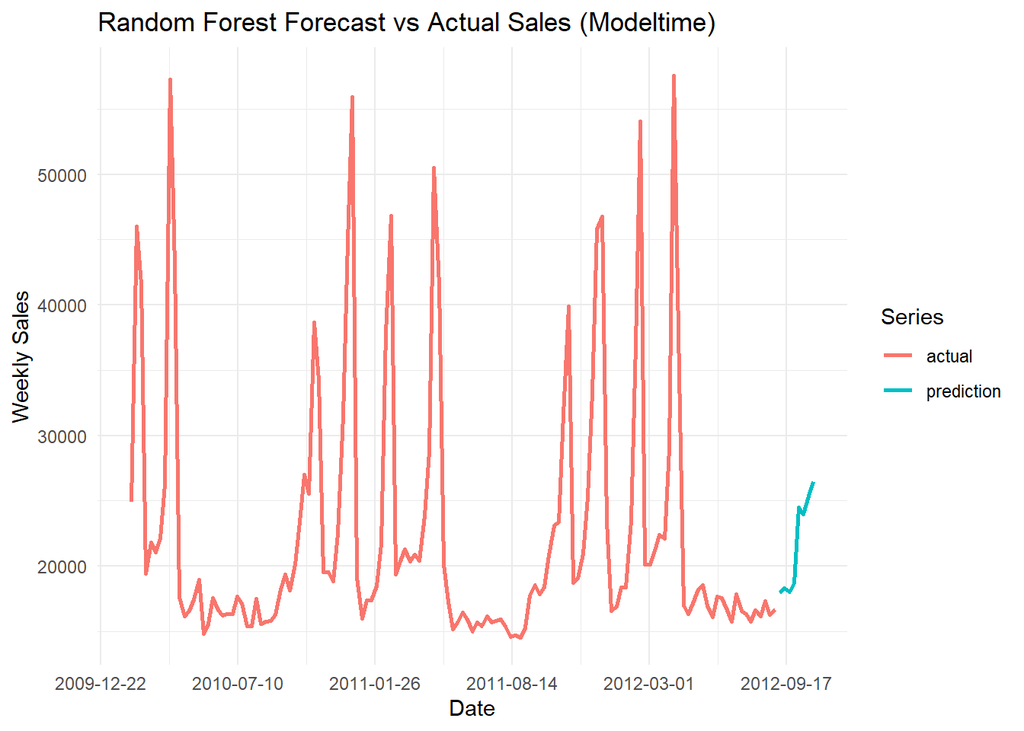

# 6 Model Comparison & Business Analysis

Error Metrics Summary by Model

[output not shown]

Error Metrics (Long Format)

[output not shown]

[figure not shown]

**Business Insights & Recommendations:**

- **Inventory Management:**  
  Accurate forecasts enable rational inventory allocation. For example, if a particular store is expected to experience a significant sales spike during a holiday, inventory can be increased accordingly; conversely, inventory can be reduced during low-sales periods.
- **Marketing Strategy:**  
  Analyzing model performance during promotional periods helps to tailor targeted promotional plans and advertising spend for better effectiveness.
- **Resource Allocation:**  
  Precise forecasts facilitate optimized staffing and logistics planning, ensuring efficient resource distribution and lower operational costs.

# 7 Conclusion & Recommendations